# Head/Tails breaks

Diego Hernangomez

2023-09-05

> *There are far more ordinary people (say, 80 percent) than extraordinary people (say, 20 percent); this is often characterized by the 80/20 principle, based on the observation made by the Italian economist Vilfredo Pareto in 1906 that 80% of land in Italy was owned by 20% of the population. A histogram of the data values for these phenomena would reveal a right-skewed or heavy-tailed distribution. How to map the data with the heavy-tailed distribution?*

> Jiang (2013)

# Abstract

This vignette discusses the implementation of the “Head/tail breaks” style (Jiang (2013)) in the `classIntervals` function. A step-by-step example is presented in order to clarify the method. A case study using `spData::afcon` is also included, as well as a test suite checking the performance and validation of the implementation.

# Introduction

The **Head/tail breaks**, sometimes referred as **ht-index** (Jiang and Yin (2013)), is a classification scheme introduced by Jiang (2013) in order to find groupings or hierarchy for data with a heavy-tailed distribution.

Heavy-tailed distributions are heavily right skewed, with a minority of large values in the head and a majority of small values in the tail. This imbalance between the head and tail, or between many small values and a few large values, can be expressed as *“far more small things than large things”*.

Heavy tailed distributions are commonly characterized by a power law, a lognormal or an exponential function. Nature, society, finance (Vasicek (2002)) and our daily lives are full of rare and extreme events, which are termed “black swan events” (Taleb (2008)). This line of thinking provides a good reason to reverse our thinking by focusing on low-frequency events.

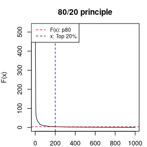

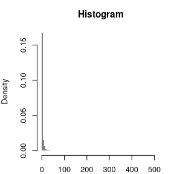

```r
library(classInt)

#1. Characterization of heavy-tail distributions----
set.seed(1234)
#Pareto distribution a=1 b=1.161 n=1000
sample_par <- 1 / (1 - runif(1000)) ^ (1 / 1.161)
opar <- par(no.readonly = TRUE)
par(mar = c(2, 4, 3, 1), cex = 0.8)
plot(
  sort(sample_par, decreasing = TRUE),
  type = "l",
  ylab = "F(x)",
  xlab = "",
  main = "80/20 principle"
)
abline(h = quantile(sample_par, .8) ,
       lty = 2,
       col = "red3")
abline(v = 0.2*length(sample_par) ,
       lty = 2,
       col = "darkblue")
legend(
  "topleft",
  legend = c("F(x): p80", "x: Top 20%"),
  col = c("red3", "darkblue"),
  lty = 2,
  cex = 0.8
)

hist(
  sample_par,
  n = 100,
  xlab = "",
  main = "Histogram",
  col = "grey50",
  border = NA,
  probability = TRUE
)
par(opar)
```

# Breaking method

The method itself consists on a four-step process performed recursively until a stopping condition is satisfied. Given a vector of values `var` the process can be described as follows:

1. Compute `mu = mean(var)`.
2. Break `var` into the `tail` (as `var < mu`) and the `head` (as `var > mu`).
3. Assess if the proportion of `head` over `var` is lower or equal than a given threshold (i.e. `length(head)/length(var) <= thr`)
4. If 3 is `TRUE`, repeat 1 to 3 until the condition is `FALSE` or no more partitions are possible (i.e. `head` has less than two elements expressed as `length(head) < 2`).

It is important to note that, at the beginning of a new iteration, `var` is replaced by `head`. The underlying hypothesis is to create partitions until the head and the tail are balanced in terms of distribution.So the stopping criteria is satisfied when the last head and the last tail are evenly balanced.

In terms of threshold, Jiang, Liu, and Jia (2013) set 40% as a good approximation, meaning that if the head contains more than 40% of the observations the distribution is not considered heavy-tailed.

The final breaks are the vector of consecutive `mu`.

# Step by step example

We reproduce here the pseudo-code[^1] as per Jiang (2019):

```
Recursive function Head/tail Breaks:
 Rank the input data from the largest to the smallest
 Break the data into the head and the tail around the mean;
 // the head for those above the mean
 // the tail for those below the mean
 While (head <= 40%):
 Head/tail Breaks (head);
End Function
```

A step-by-step example in **R** (for illustrative purposes) has been developed:

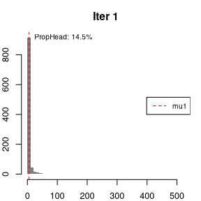

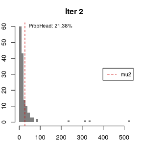

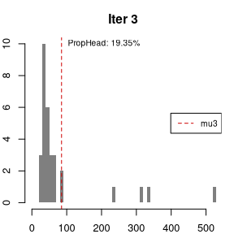

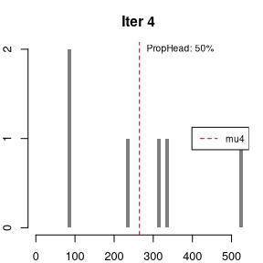

```r
opar <- par(no.readonly = TRUE)
par(mar = c(2, 2, 3, 1), cex = 0.8)
var <- sample_par
thr <- .4
brks <- c(min(var), max(var))  #Initialise with min and max

sum_table <- data.frame(
  iter = 0,
  mu = NA,
  prop = NA,
  n_var = NA,
  n_head = NA
)
#Pars for chart
limchart <- brks
#Iteration
for (i in 1:10) {
  mu <- mean(var)
  brks <- sort(c(brks, mu))
  head <- var[var > mu]
  prop <- length(head) / length(var)
  stopit <- prop < thr & length(head) > 1
  sum_table = rbind(sum_table,
                    c(i, mu, prop, length(var), length(head)))
  hist(
    var,
    main = paste0("Iter ", i),
    breaks = 50,
    col = "grey50",
    border = NA,
    xlab = "",
    xlim = limchart
  )
  abline(v = mu, col = "red3", lty = 2)
  ylabel <- max(hist(var, breaks = 50, plot = FALSE)$counts)
  labelplot <- paste0("PropHead: ", round(prop * 100, 2), "%")
  text(
    x = mu,
    y = ylabel,
    labels = labelplot,
    cex = 0.8,
    pos = 4
  )
  legend(
    "right",
    legend = paste0("mu", i),
    col = c("red3"),
    lty = 2,
    cex = 0.8
  )
  if (isFALSE(stopit))
    break
  var <- head
}
par(opar)
```

As it can be seen, in each iteration the resulting head gradually loses the high-tail property, until the stopping condition is met.

| iter | mu | prop | n_var | n_head |
| --- | --- | --- | --- | --- |
| 1 | 5.6755 | 14.5% | 1000 | 145 |
| 2 | 27.2369 | 21.38% | 145 | 31 |
| 3 | 85.1766 | 19.35% | 31 | 6 |
| 4 | 264.7126 | 50% | 6 | 3 |

The resulting breaks are then defined as `breaks = c(min(var), mu(iter=1), ..., mu(iter), max(var))`.

# Implementation in `classInt` package

The implementation in the `classIntervals` function should replicate the results:

```r
ht_sample_par <- classIntervals(sample_par, style = "headtails")
brks == ht_sample_par$brks
```

```
#> [1] TRUE TRUE TRUE TRUE TRUE TRUE
```

```r
print(ht_sample_par)
```

```
#> style: headtails
#> [1.000295,5.675463) [5.675463,27.23693) [27.23693,85.17664) [85.17664,264.7126)
#>                 855                 114                  25                   3
#> [264.7126,523.6254]
#>                   3
```

As stated in Jiang (2013), the number of breaks is naturally determined, however the `thr` parameter could help to adjust the final number. A lower value on `thr` would provide less breaks while a larger `thr` would increase the number, if the underlying distribution follows the *“far more small things than large things”* principle.

```r
opar <- par(no.readonly = TRUE)
par(mar = c(2, 2, 2, 1), cex = 0.8)

pal1 <- c("wheat1", "wheat2", "red3")

# Minimum: single break
print(classIntervals(sample_par, style = "headtails", thr = 0))
```

```
#> style: headtails
#> [1.000295,5.675463) [5.675463,523.6254]
#>                 855                 145
```

```r
plot(
  classIntervals(sample_par, style = "headtails", thr = 0),
  pal = pal1,
  main = "thr = 0"
)

# Two breaks
print(classIntervals(sample_par, style = "headtails", thr = 0.2))
```

```
#> style: headtails
#> [1.000295,5.675463) [5.675463,27.23693) [27.23693,523.6254]
#>                 855                 114                  31
```

```r
plot(
  classIntervals(sample_par, style = "headtails", thr = 0.2),
  pal = pal1,
  main = "thr = 0.2"
)

# Default breaks: 0.4
print(classIntervals(sample_par, style = "headtails"))
```

```
#> style: headtails
#> [1.000295,5.675463) [5.675463,27.23693) [27.23693,85.17664) [85.17664,264.7126)
#>                 855                 114                  25                   3
#> [264.7126,523.6254]
#>                   3
```

```r
plot(classIntervals(sample_par, style = "headtails"),
     pal = pal1,
     main = "thr = Default")

# Maximum breaks
print(classIntervals(sample_par, style = "headtails", thr = 1))
```

```
#> style: headtails
#> [1.000295,5.675463) [5.675463,27.23693) [27.23693,85.17664) [85.17664,264.7126)
#>                 855                 114                  25                   3
#>  [264.7126,391.279)  [391.279,523.6254]
#>                   2                   1
```

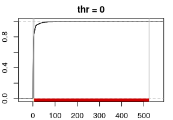

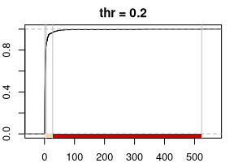

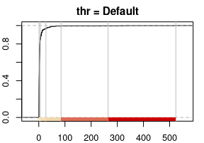

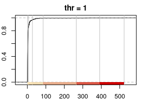

```r
plot(
  classIntervals(sample_par, style = "headtails", thr = 1),
  pal = pal1,
  main = "thr = 1"
)
par(opar)
```

The method always returns at least one break, corresponding to `mean(var)`.

# Case study

Jiang (2013) states that “the new classification scheme is more natural than the natural breaks in finding the groupings or hierarchy for data with a heavy-tailed distribution.” (p. 482), referring to Jenks’ natural breaks method. In this case study we would compare “headtails” vs. “fisher”, that is the alias for the Fisher-Jenks algorithm and it is always preferred to the “jenks” style (see `?classIntervals`). For this example we will use the `afcon` dataset from `spData` package.

```r
library(spData)
data(afcon, package = "spData")
```

Let’s have a look to the Top 10 values and the distribution of the variable `totcon` (index of total conflict 1966-78):

```r
# Top10
knitr::kable(head(afcon[order(afcon$totcon, decreasing = TRUE),c("name","totcon")],10))
```

|  | name | totcon |
| --- | --- | --- |
| EG | EGYPT | 5246 |
| SU | SUDAN | 4751 |
| UG | UGANDA | 3134 |
| CG | ZAIRE | 3087 |
| TZ | TANZANIA | 2881 |
| LY | LIBYA | 2355 |
| KE | KENYA | 2273 |
| SO | SOMALIA | 2122 |
| ET | ETHIOPIA | 1878 |
| SF | SOUTH AFRICA | 1875 |

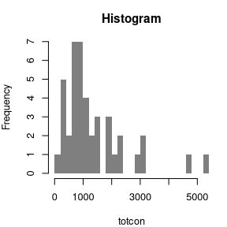

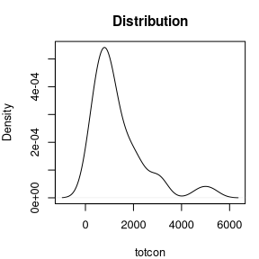

```r
opar <- par(no.readonly = TRUE)
par(mar = c(4, 4, 3, 1), cex = 0.8)
hist(afcon$totcon,
     n = 20,
     main = "Histogram",
     xlab = "totcon",
     col = "grey50",
     border = NA, )
plot(
  density(afcon$totcon),
  main = "Distribution",
  xlab = "totcon",
)
par(opar)
```

The data shows that EG and SU data present a clear hierarchy over the rest of values. As per the histogram, we can confirm a heavy-tailed distribution and therefore the *“far more small things than large things”* principle.

As a testing proof, on top of “headtails” and “fisher” we would use also “quantile” to have a broader view on the different breaking styles. As “quantile” is a position-based metric, it doesn’t account for the magnitude of F(x) (hierarchy), so the breaks are solely defined by the position of x on the distribution.

Applying the three aforementioned methods to break the data:

```r
brks_ht <- classIntervals(afcon$totcon, style = "headtails")
print(brks_ht)
```

```
#> style: headtails
#>   one of 91,390 possible partitions of this variable into 5 classes
#>    [147,1350.619) [1350.619,2488.6)   [2488.6,3819.8)   [3819.8,4998.5)
#>                27                10                 3                 1
#>     [4998.5,5246]
#>                 1
```

```r
#Same number of classes for "fisher"
nclass <- length(brks_ht$brks) - 1
brks_fisher <-  classIntervals(afcon$totcon, style = "fisher",
                               n = nclass)
print(brks_fisher)
```

```
#> style: fisher
#>   one of 91,390 possible partitions of this variable into 5 classes
#>    [147,693.5) [693.5,1474.5)  [1474.5,2618)  [2618,3942.5)  [3942.5,5246]
#>             12             17              8              3              2
```

```r
brks_quantile <- classIntervals(afcon$totcon, style = "quantile",
                                n = nclass)
print(brks_quantile)
```

```
#> style: quantile
#>   one of 91,390 possible partitions of this variable into 5 classes
#>       [147,604)     [604,833.6)  [833.6,1137.2) [1137.2,1877.4)   [1877.4,5246]
#>               8               9               8               8               9
```

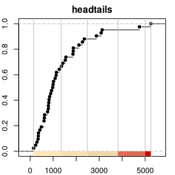

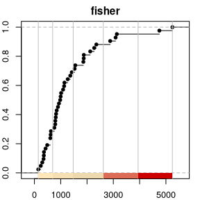

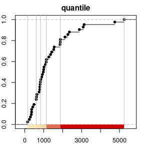

```r
pal1 <- c("wheat1", "wheat2", "red3")
opar <- par(no.readonly = TRUE)
par(mar = c(2, 2, 2, 1), cex = 0.8)
plot(brks_ht, pal = pal1, main = "headtails")
plot(brks_fisher, pal = pal1, main = "fisher")
plot(brks_quantile, pal = pal1, main = "quantile")
par(opar)
```

It is observed that the top three classes of “headtails” enclose 5 observations, whereas “fisher” includes 13 observations. In terms of classification, “headtails” breaks focuses more on extreme values.

The next plot compares a continuous distribution of `totcon` re-escalated to a range of `[1,nclass]` versus the distribution across breaks for each style. The continuous distribution has been offset by -0.5 in order to align the continuous and the discrete distributions.

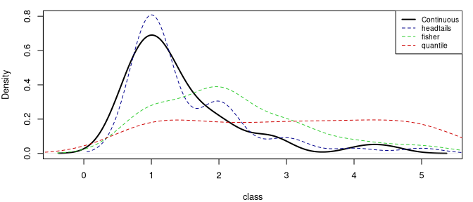

```r
#Helper function to rescale values
help_reescale <- function(x, min = 1, max = 10) {
  r <- (x - min(x)) / (max(x) - min(x))
  r <- r * (max - min) + min
  return(r)
}
afcon$ecdf_class <- help_reescale(afcon$totcon,
                                  min = 1 - 0.5,
                                  max = nclass - 0.5)
afcon$ht_breaks <-  cut(afcon$totcon,
                        brks_ht$brks,
                        labels = FALSE,
                        include.lowest = TRUE)

afcon$fisher_breaks <-  cut(afcon$totcon,
                            brks_fisher$brks,
                            labels = FALSE,
                            include.lowest = TRUE)

afcon$quantile_break <-  cut(afcon$totcon,
                             brks_quantile$brks,
                             labels = FALSE,
                             include.lowest = TRUE)

opar <- par(no.readonly = TRUE)
par(mar = c(4, 4, 1, 1), cex = 0.8)
plot(
  density(afcon$ecdf_class),
  ylim = c(0, 0.8),
  lwd = 2,
  main = "",
  xlab = "class"
)
lines(density(afcon$ht_breaks), col = "darkblue", lty = 2)
lines(density(afcon$fisher_breaks), col = "limegreen", lty = 2)
lines(density(afcon$quantile_break),
      col = "red3",
      lty = 2)
legend("topright",
       legend = c("Continuous", "headtails",
                  "fisher", "quantile"),
  col = c("black", "darkblue", "limegreen", "red3"),
  lwd = c(2, 1, 1, 1),
  lty = c(1, 2, 2, 2),
  cex = 0.8
)
par(opar)
```

It can be observed that the distribution of “headtails” breaks is also heavy-tailed, and closer to the original distribution. On the other extreme, “quantile” provides a quasi-uniform distribution, ignoring the `totcon` hierarchy

In terms of data visualization, we compare here the final map using the techniques mentioned above. On this plotting exercise:

- `cex` of points are always between `1` and `5`.
- For the continuous approach, no classes are provided. This plot will be used as the reference.
- For all the rest of styles, `col` and `cex` on each point is defined as per the class of that point.

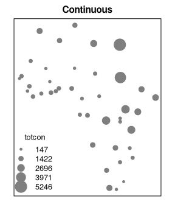

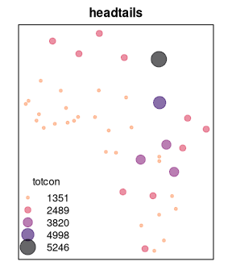

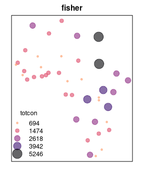

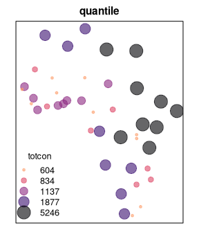

```r
custompal <- c("#FE9F6D99",
               "#DE496899",
               "#8C298199",
               "#3B0F7099",
               "#00000499")

afcon$cex_points <- help_reescale(afcon$totcon,
                                  min = 1,
                                  max = 5)
opar <- par(no.readonly = TRUE)
par(mar = c(1.5, 1.5, 2, 1.5), cex = 0.8)
# Plot continuous
plot(
  x = afcon$x,
  y = afcon$y,
  axes = FALSE,
  cex = afcon$cex_points,
  pch = 20,
  col = "grey50",
  main = "Continuous",
)

mcont <- (max(afcon$totcon) - min(afcon$totcon)) / 4
legcont <- 1:5 * mcont - (mcont - min(afcon$totcon))

legend("bottomleft",
       xjust = 1,
       bty = "n",
       legend = paste0("   ",
                  round(legcont, 0)
                  ),
       col = "grey50",
  pt.cex = seq(1, 5),
  pch = 20,
  title = "totcon"
)
box()

plot(
  x = afcon$x,
  y = afcon$y,
  axes = FALSE,
  cex = afcon$ht_breaks,
  pch = 20,
  col = custompal[afcon$ht_breaks],
  main = "headtails"
)
legend(
  "bottomleft",
  xjust = 1,
  bty = "n",
  legend = paste0("   ",
                  round(brks_ht$brks[2:6],0)
                  ),
  col = custompal,
  pt.cex = seq(1, 5),
  pch = 20,
  title = "totcon"
)
box()

plot(
  x = afcon$x,
  y = afcon$y,
  axes = FALSE,
  cex = afcon$fisher_breaks,
  pch = 20,
  col = custompal[afcon$fisher_breaks],
  main = "fisher"
)
legend(
  "bottomleft",
  xjust = 1,
  bty = "n",
  legend = paste0("   ",
                  round(brks_fisher$brks[2:6],0)
                  ),
  col = custompal,
  pt.cex = seq(1, 5),
  pch = 20,
  title = "totcon"
)
box()

plot(
  x = afcon$x,
  y = afcon$y,
  axes = FALSE,
  cex = afcon$quantile_break,
  pch = 20,
  col = custompal[afcon$quantile_break],
  main = "quantile"
)
legend(
  "bottomleft",
  xjust = 1,
  bty = "n",
  legend = paste0("   ",
                  round(brks_quantile$brks[2:6],0)
                  ),
  col = custompal,
  pt.cex = seq(1, 5),
  pch = 20,
  title = "totcon"
)
box()

par(opar)
```

As per the results, “headtails” seems to provide a better understanding of the most extreme values when the result is compared against the continuous plot. The “quantile” style, as expected, just provides a clustering without taking into account the real hierarchy. The “fisher” plot is in-between of these two interpretations.

It is also important to note that “headtails” and “fisher” reveal different information that can be useful depending of the context. While “headtails” highlights the outliers, it fails on providing a good clustering on the tail, while “fisher” seems to reflect better these patterns. This can be observed on the values of Western Africa and the Niger River Basin, where “headtails” doesn’t highlight any special cluster of conflicts, “fisher” suggests a potential cluster. This can be confirmed on the histogram generated previously, where a concentration of `totcon` around 1,000 is visible.

# Testing and benchmark

On this section the performance of the “headtails” implementation is tested, in terms of speed and handling of corner cases. A small benchmark with another styles is also presented.

Testing has been performed over the following distributions:

**Non heavy-tailed distributions**

- Normal (non heavy-tailed)
- Truncated Normal (left-tailed)
- Uniform distribution

```r
#Init samples
set.seed(2389)

#Pareto distributions a=7 b=14
paretodist <- 7 / (1 - runif(5000000)) ^ (1 / 14)
#Exponential dist
expdist <- rexp(5000000)
#Lognorm
lognormdist <- rlnorm(5000000)
#Weibull
weibulldist <- rweibull(5000000, 1, scale = 5)
#LogCauchy "super-heavy tail"
logcauchdist <- exp(rcauchy(5000000, 2, 4))
#Remove Inf
logcauchdist <- logcauchdist[logcauchdist < Inf]

#Normal dist
normdist <- rnorm(5000000)
#Left-tailed distr
leftnorm <-
  sample(rep(normdist[normdist < mean(normdist)], 3), size = 5000000)

#Uniform distribution
unifdist <- runif(5000000)
```

Let’s define a helper function and proceed to run the whole test suite:

| Title | style | nsample | thresold | nbreaks | time_secs |
| --- | --- | --- | --- | --- | --- |
| Pareto | headtails | 5,000,000 | 0.40 | 15 | 0.5586 |
| Pareto | headtails | 5,000,000 | 0.00 | 2 | 0.5295 |
| Pareto | headtails | 5,000,000 | 0.75 | 15 | 0.5592 |
| Pareto sample | fisher | 2,000 | 0.40 | 12 | 0.0196 |
| Pareto sample | headtails | 2,000 | 0.40 | 8 | 3e-04 |
| Exponential | headtails | 5,000,000 | 0.40 | 16 | 0.4547 |
| Exponential | headtails | 5,000,000 | 0.00 | 2 | 0.3724 |
| Exponential | headtails | 5,000,000 | 1.00 | 17 | 0.4065 |
| Exponential | quantile | 5,000,000 | 0.40 | 24 | 0.7121 |
| Weibull | headtails | 5,000,000 | 0.40 | 16 | 0.4277 |
| Weibull | headtails | 5,000,000 | 0.00 | 2 | 0.4585 |
| Weibull | headtails | 5,000,000 | 1.00 | 17 | 0.4912 |
| LogCauchy | headtails | 4,991,187 | 0.40 | 6 | 0.5134 |
| LogCauchy | headtails | 4,991,187 | 0.00 | 2 | 0.4214 |
| LogCauchy | headtails | 4,991,187 | 1.00 | 6 | 0.3842 |
| Normal | headtails | 5,000,000 | 0.40 | 2 | 0.3906 |
| Normal | headtails | 5,000,000 | 0.00 | 2 | 0.4259 |
| Normal | headtails | 5,000,000 | 1.00 | 17 | 0.6012 |
| Left Normal | headtails | 5,000,000 | 0.40 | 2 | 0.5093 |
| Left Normal | headtails | 5,000,000 | -100.00 | 2 | 0.5749 |
| Left Normal | headtails | 5,000,000 | 500.00 | 21 | 0.626 |
| Uniform | headtails | 5,000,000 | 0.70 | 22 | 0.4728 |
| Uniform | headtails | 5,000,000 | 0.00 | 2 | 0.4215 |
| Uniform | headtails | 5,000,000 | 1.00 | 22 | 0.4693 |

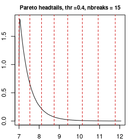

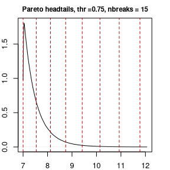

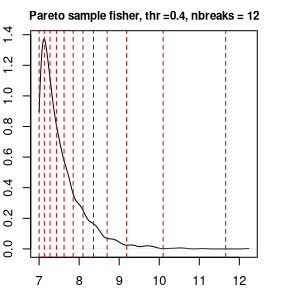

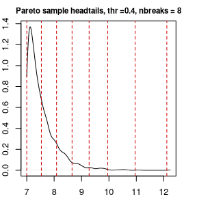

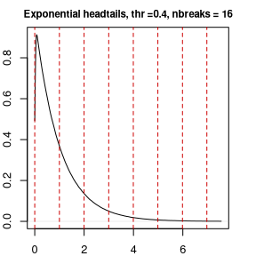

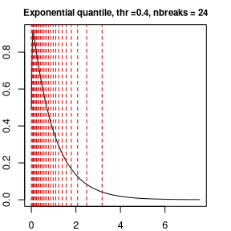

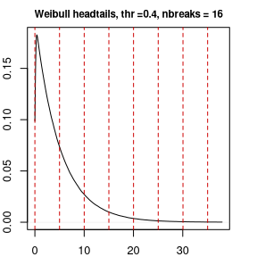

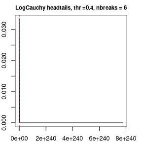

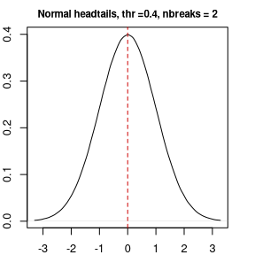

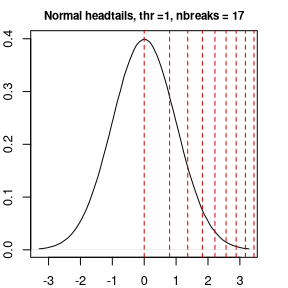

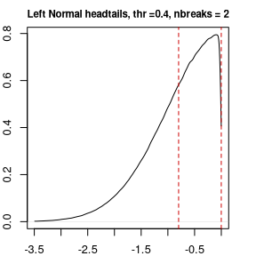

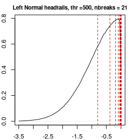

[2 more figures not shown]

```r
testresults <- data.frame(
  Title = NA,
  style = NA,
  nsample  = NA,
  thresold = NA,
  nbreaks = NA,
  time_secs = NA
)

benchmarkdist <-
  function(dist,
           style = "headtails",
           thr = 0.4,
           title = "",
           plot = FALSE) {
    init <- Sys.time()
    br <- classIntervals(dist, style = style, thr = thr)
    a <- Sys.time() - init
    test <- data.frame(
      Title = title,
      style  = style,
      nsample  = format(length(br$var),
                        scientific = FALSE, big.mark = ","),
      thresold = thr,
      nbreaks = length(br$brks) - 1,
      time_secs = as.character(round(a,4))
    )
    testresults <- unique(rbind(testresults, test))

    if (plot) {
      plot(
        density(br$var,
                from = quantile(dist,.0005),
                to = quantile(dist,.9995)
                ),
        col = "black",
        cex.main = .9,
        main = paste0(
          title,
          " ",
          style,
          ", thr =",
          thr,
          ", nbreaks = ",
          length(br$brks) - 1
        ),
        ylab = "",
        xlab = ""
      )
      abline(v = br$brks,
             col = "red3",
             lty = 2)
    }
    return(testresults)
  }
opar <- par(no.readonly = TRUE)
par(mar = c(2, 2, 2, 2), cex = 0.8)

# Pareto----
testresults <- benchmarkdist(paretodist, title = "Pareto", plot = TRUE)
testresults <- benchmarkdist(paretodist, title = "Pareto", thr = 0)
testresults <- benchmarkdist(paretodist, title = "Pareto", thr = .75, plot = TRUE)

#Sample 2,000 obs
set.seed(1234)
Paretosamp <- sample(paretodist, 2000)
testresults <- benchmarkdist(Paretosamp,
                             title = "Pareto sample",
                             style = "fisher",
                             plot = TRUE)
testresults <- benchmarkdist(Paretosamp,
                             title = "Pareto sample",
                             style = "headtails",
                             plot = TRUE)


#Exponential----
testresults <- benchmarkdist(expdist, title = "Exponential", plot = TRUE)
testresults <- benchmarkdist(expdist, title = "Exponential", thr = 0)
testresults <- benchmarkdist(expdist, title = "Exponential", thr = 1)
testresults <- benchmarkdist(expdist, title = "Exponential",
                             style = "quantile", plot = TRUE)

#Weibull-----
testresults <- benchmarkdist(weibulldist, title = "Weibull", plot = TRUE)
testresults <- benchmarkdist(weibulldist, title = "Weibull", thr = 0)
testresults <- benchmarkdist(weibulldist, title = "Weibull", thr = 1)

#Logcauchy
testresults <- benchmarkdist(logcauchdist, title = "LogCauchy", plot = TRUE)
testresults <- benchmarkdist(logcauchdist, title = "LogCauchy", thr = 0)
testresults <- benchmarkdist(logcauchdist, title = "LogCauchy", thr = 1)

#Normal----
testresults <- benchmarkdist(normdist, title = "Normal", plot = TRUE)
testresults <- benchmarkdist(normdist, title = "Normal", thr = 0)
testresults <- benchmarkdist(normdist, title = "Normal", thr = 1, plot = TRUE)

#Truncated Left-tail Normal----
testresults <- benchmarkdist(leftnorm, title = "Left Normal", plot = TRUE)
testresults <- benchmarkdist(leftnorm, title = "Left Normal", thr = -100)
testresults <- benchmarkdist(leftnorm, title = "Left Normal", plot = TRUE, thr = 500)

#Uniform----
testresults <- benchmarkdist(unifdist, title = "Uniform", plot = TRUE, thr = 0.7)
testresults <- benchmarkdist(unifdist, title = "Uniform", thr = 0)
testresults <- benchmarkdist(unifdist, title = "Uniform", plot = TRUE, thr = 1)
par(opar)

# Results
knitr::kable(testresults[-1, ], row.names = FALSE)
```

The implementation works as expected, with a good performance given the size of the sample, and also compares well with another current implementations in `classIntervals`.

# References

Falk, Michael, Juerg Huesler, and Rolf-Dieter Reiss. 2011. *Laws of Small Numbers: Extremes and Rare Events*. *Laws of Small Numbers: Extremes and Rare Events*. https://doi.org/10.1007/978-3-0348-0009-9.

Fraga Alves, Maria, L. D. Haan, and Claudia Neves. 2009. “Statistical Inference for Heavy and Super-Heavy Tailed Distributions.” *J. Stat. Plan. Inf.* 139 (January): 213–27.

Jiang, Bin. 2013. “Head/Tail Breaks: A New Classification Scheme for Data with a Heavy-Tailed Distribution.” *The Professional Geographer* 65 (3): 482–94. https://doi.org/10.1080/00330124.2012.700499.

———. 2019. “A Recursive Definition of Goodness of Space for Bridging the Concepts of Space and Place for Sustainability.” *Sustainability* 11 (15): 4091. https://doi.org/10.3390/su11154091.

Jiang, Bin, Xintao Liu, and Tao Jia. 2013. “Scaling of Geographic Space as a Universal Rule for Map Generalization.” *Annals of the Association of American Geographers* 103 (4): 844–55. https://doi.org/10.1080/00045608.2013.765773.

Jiang, Bin, and Junjun Yin. 2013. “Ht-Index for Quantifying the Fractal or Scaling Structure of Geographic Features.” *Annals of the Association of American Geographers* 104 (3): 530–40. https://doi.org/10.1080/00045608.2013.834239.

Taleb, Nassim Nicholas. 2008. *The Black Swan: The Impact of the Highly Improbable*. 1st ed. London: Random House.

Vasicek, Oldrich. 2002. “Loan Portfolio Value.” *Risk*, December, 160–62.

[^1]: The method implemented in `classInt` corresponds to head/tails 1.0 as named in this article.